# QMSS R Tutorial Part 4: Processing data

# 1 Basic stats

In the last section, we used a database of word orders. We’ll use that again here:

```r
setwd("~/Documents/Teaching/JenaSpringSchool/org/spring-school/IntroToR")
d <- read.csv("data/WALS_WordOrder.csv", stringsAsFactors = F)
glottoData <- read.csv("data/Glottolog_Data.csv", stringsAsFactors = F)
d2 <- merge(d, glottoData, by.x='glottocode', by.y='glotto.code')
```

The data frame `d2` now includes variables **latitude** and **family**.

## 1.1 Mean, standard deviation, minimum and maximum

What is the mean latitude of languages?

The function `mean` takes a numeric vector and returns the mean (average). Other simple functions include `sd`, `max` and `min`:

```r
mean(d2$latitude)
```

```
## [1] 10.459
```

```r
sd(d2$latitude)
```

```
## [1] 21.21768
```

```r
max(d2$latitude)
```

```
## [1] 69
```

```r
min(d2$latitude)
```

```
## [1] -53
```

Most languages are within about 20 degress of the 10th parallel!

## 1.2 Basic statistics

I predict that the mean latitude of SOV should be greater than the mean latitude of VOS.

To test this, I make two variables: one of latitudes for SOV languages and one for latitude for VOS languages. I then pass these two to the function `t.test` which runs a two-sample t-test:

```r
SOV.latitude = d2[d2$BasicWordOrder=="SOV",]$latitude
VOS.latitude = d2[d2$BasicWordOrder=="VOS",]$latitude

t.test(SOV.latitude, VOS.latitude)
```

```
##
##  Welch Two Sample t-test
##
## data:  SOV.latitude and VOS.latitude
## t = 2.4084, df = 19.351, p-value = 0.02614
## alternative hypothesis: true difference in means is not equal to 0
## 95 percent confidence interval:
##   1.473123 20.847449
## sample estimates:
## mean of x mean of y
## 14.399175  3.238889
```

The output to the conslode has a lot of statistics, including the pvalue and t score, and mean of each group. We can also assign the result to a variable, from which we can access individual parts of the results.

```r
tResult <- t.test(SOV.latitude, VOS.latitude)
tResult$statistic
```

```
##        t
## 2.408355
```

```r
tResult$p.value
```

```
## [1] 0.02614253
```

My hypothesis is correct and I have changed the course of linguistics.

To go further, I test whether latitude is predicted more widely by basic word order or adposition. I use a *linear model* using `lm`. This takes a *function* as an argument, alongside a data frame of data.

A function has a dependent variable first, followed by a tilde `~`, then a list of dependent variables seperated by `+`. All variables should be present in the data frame d2:

```r
model1 = lm(latitude ~ BasicWordOrder + AdpositionOrder, data=d2)
```

The `summary` function gives us a table of parameter estimates, t-values and p-values.

```r
summary(model1)
```

```
##
## Call:
## lm(formula = latitude ~ BasicWordOrder + AdpositionOrder, data = d2)
##
## Residuals:
##     Min      1Q  Median      3Q     Max
## -54.968 -15.185  -1.937  12.491  62.179
##
## Coefficients:
##                                  Estimate Std. Error t value Pr(>|t|)
## (Intercept)                        -9.471      7.867  -1.204 0.228923
## BasicWordOrderOSV                 -20.155     12.199  -1.652 0.098827 .
## BasicWordOrderOVS                 -22.969      6.883  -3.337 0.000881 ***
## BasicWordOrderSOV                   1.565      2.512   0.623 0.533344
## BasicWordOrderSVO                  -6.306      2.458  -2.565 0.010462 *
## BasicWordOrderVOS                  -9.280      5.394  -1.720 0.085703 .
## BasicWordOrderVSO                   2.313      3.289   0.703 0.482013
## AdpositionOrderNo adpositions      19.687      8.850   2.225 0.026353 *
## AdpositionOrderNo dominant order   19.746      8.477   2.329 0.020059 *
## AdpositionOrderPostpositions       22.598      8.027   2.815 0.004977 **
## AdpositionOrderPrepositions        22.126      8.111   2.728 0.006494 **
## ---
## Signif. codes:  0 '***' 0.001 '**' 0.01 '*' 0.05 '.' 0.1 ' ' 1
##
## Residual standard error: 20.73 on 929 degrees of freedom
## Multiple R-squared:  0.05591,    Adjusted R-squared:  0.04575
## F-statistic: 5.502 on 10 and 929 DF,  p-value: 5.567e-08
```

No need to worry about the theory now, just the basic idea: You can apply regression or other statistical tests to a set of data, and assign the results to a variable. That variable (`model1` above) now stores the output of the statistical test.

## 1.3 tapply

Which language family has the greatest spread in latitude?

For this we need to use `tapply`, which takes a vector of objects, groups the objects according to a second vector, then applies a function to each group.

For example, this code works out the standard deviation of languages within each family. The first argument is what we want to process, the second argument defines how we want to group the data, the thrid argument is the funciton we want to apply (without brackets).

```r
langFamLatitudeSD <- tapply(d2$latitude, d2$glotto.family, sd)
```

We then sort the data using `sort` (in decreasing order) and show the first few results using `head`.

```r
langFamLatitudeSD.sorted <- sort(langFamLatitudeSD, decreasing = TRUE)
head(langFamLatitudeSD.sorted)
```

```
##           Indo-European Athapaskan-Eyak-Tlingit            Austronesian
##               12.743134               11.763143               10.316753
##          Atlantic-Congo            Afro-Asiatic                  Turkic
##                9.687191                9.612040                9.270248
```

Indo-European has the highest standard deviation of languages by latitude!

> **Task**: Which basic word order type has the higest mean latitude?

## 1.4 Custom functions

Which language family has the largest *range* in latitude?

To answer this, we need to know the difference between the maximum and minimum latitude for each family. There’s no simple function that can calculate this, but we can make our own.

First, how would be calculate the range? Given the list of numbers below, we can work out the maximum and minimum value, then subtract one from the other:

```r
x <- c(1,4,6,2,99,2)
max(x) - min(x)
```

```
## [1] 98
```

Functions in R are defined similarly to other objects. Below we create a function called `rangeDiff` which takes one argument (a list of numbers) and returns one number (the range of the numbers).

- We declare it to be a function with one argument named `x`.
- We use curly brackets to indicate where the code of the function begins and ends.
- Then we create a variable `r` which calculates the range.
- We pass the value of `r` back to the user with the function `return`.

```r
rangeDiff <- function(x){
  r <- max(x) - min(x)
  return(r)
}
```

After running these lines, nothing will happen, but we can now use this function in other parts of the code.

```r
x <- c(1,4,6,2,99,2)
rangeDiff(x)
```

```
## [1] 98
```

```r
lotteryNums <- c(64,92,47,11)
rangeDiff(lotteryNums)
```

```
## [1] 81
```

Now we can use `rangeDiff` to work out the range for each language family:

```r
langFamLatitudeRange <- tapply(d2$latitude, d2$glotto.family, rangeDiff)
langFamLatitudeRange.sorted <- sort(langFamLatitudeRange, decreasing = TRUE)
head(langFamLatitudeRange.sorted)
```

```
##            Austronesian           Indo-European          Atlantic-Congo
##                63.33333                60.50000                47.25000
##            Afro-Asiatic Athapaskan-Eyak-Tlingit                  Tupian
##                41.83333                30.83333                29.16667
```

Austronesian has the largest range in languages by latitude!

# 2 Making plots

Plots are made using functions, too. The most basic function is `plot`, which just makes an x-by-y plot.

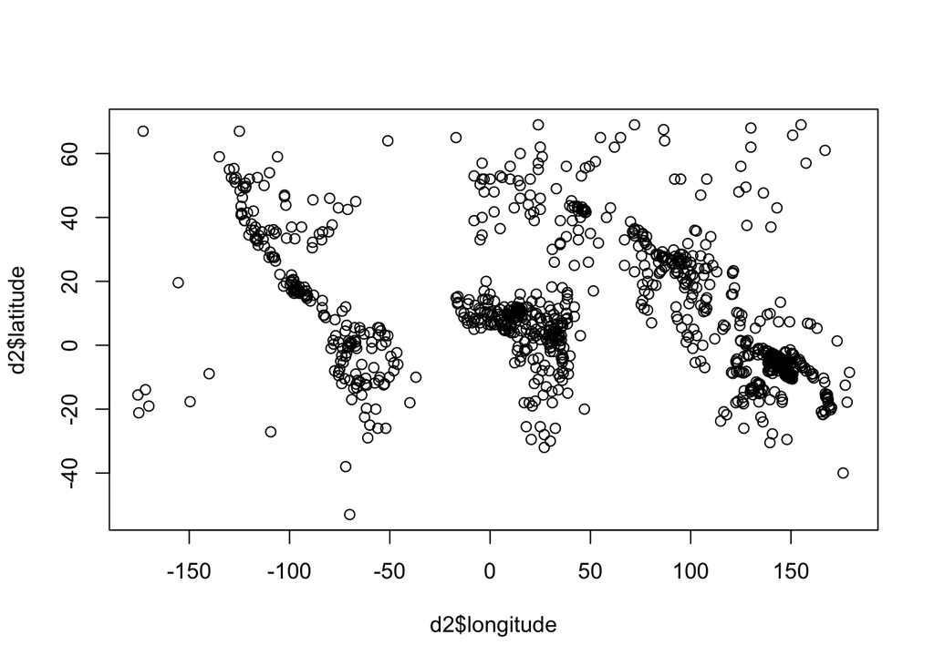

```r
plot(d2$longitude, d2$latitude)
```

`hist` is a function which produces a histogram:

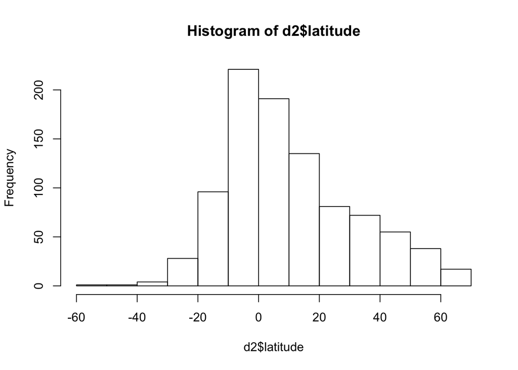

```r
hist(d2$latitude)
```

The `maps` package helps plot maps:

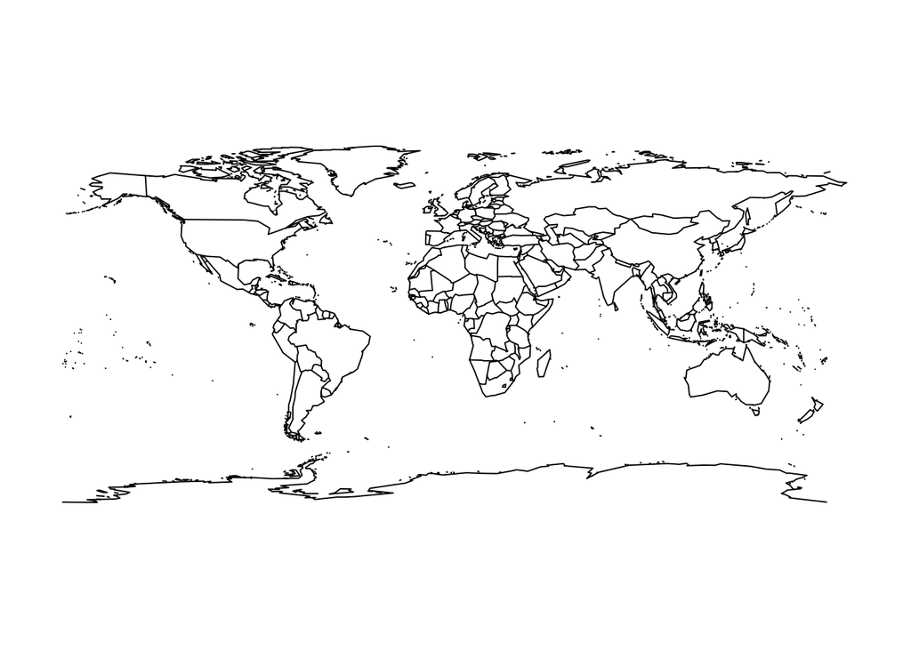

```r
library(maps)
map()
```

This produces a map of the world and displays it in the plot window. We can add stuff on top with functions like `points` and `abline`:

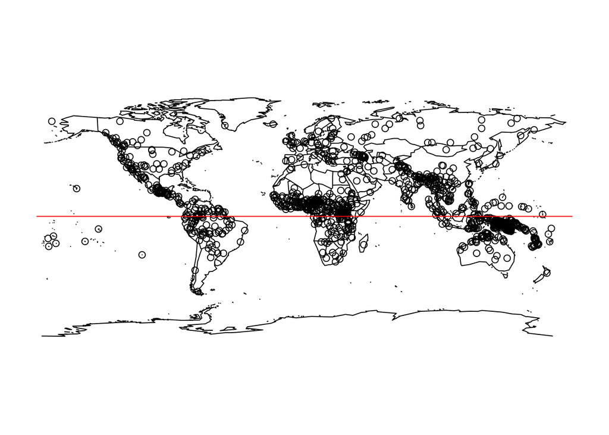

```r
# draw a map of the world
map()
# add locations of languages
points(d2$longitude, d2$latitude)
# add a horizontal line at the equator
abline(h = 0, col = 2)
```

There are many other types of plot. The easiest way to find a recipie for making a plot is to use a gallery ([like this one](http://www.r-graph-gallery.com/)).

## 2.1 Colours

Note the two extra arguments in abline. The first states that the line should be horizontal, at position 0 on the y axis, and the second indicates the colour that the line should be.

Colours in R can be specified using:

- Numbers referring to the default *palette*, 1 = black, 2 = red, 3 = green etc.
- A character string of basic colour names
- A hex or RGB value, usually produced using a helpful function like `rainbow`, `heat.colors` or the `RColorBrewer` package.

## 2.2 Writing plots to files

You can write plots to a pdf using the function `pdf`. Add the `pdf` funciton before the first plotting command, then `dev.off()` to stop writing to the file.

```r
# start writing
pdf(file="images/myMap.pdf", width= 7, height = 7)
  # draw a map of the world
  map()
  # add locations of languages
  points(d2$longitude, d2$latitude)
  # add a horizontal line at the equator
  abline(h = 0, col = 2)
# stop writing.
dev.off()
```

Go to the next tutorial

Back to the index